# Marketing Analysis Project

## Project's description

We have 3 csv datasets from Yandex Afisha database (Yandex Afisha is the biggest russian prlatform created to aggregate tickets to different kind of actions like music festivals, cinemas, theaters and others).

Our data's describing period from *june of 2017* to *may of 2018* and contains:

1. Information about visits on the website;
2. Orders by the period;
3. Advertising costs statistics.

*Monetary units in form of USD.*

Our goal is to find the way how we can pull advertising costs down (refuse from non-benefitable traffic sources and redistribute the budget).

What should we define in our project:

1. How costumers use our platform;
2. When they usually make the first orders on the website;
3. How much each costumer brings to our company;
4. When costs for costumers attraction pay off.

# Data loading and preparation to analysis process

```python
#setting up the libraries
import pandas as pd
import seaborn as sns
import matplotlib.pyplot as plt
import numpy as np
import warnings
!pip install nbconvert

#making warnings hidden
warnings.filterwarnings('ignore')
```

```python
#uploading of datasets
visits = pd.read_csv('/datasets/visits_log.csv')
orders = pd.read_csv('/datasets/orders_log.csv')
costs = pd.read_csv('/datasets/costs.csv')
```

```python
#making cycle to meet with data

list = [visits, orders, costs]
for i in list:
    display(i.head())
    i.info()
    display(i.duplicated().sum())
    display(i.isna().sum())
    print('     ')
    print('----- The End of information about table in order -----')
    print('     ')
```

|  | Device | End Ts | Source Id | Start Ts | Uid |
| --- | --- | --- | --- | --- | --- |
| 0 | touch | 2017-12-20 17:38:00 | 4 | 2017-12-20 17:20:00 | 16879256277535980062 |
| 1 | desktop | 2018-02-19 17:21:00 | 2 | 2018-02-19 16:53:00 | 104060357244891740 |
| 2 | touch | 2017-07-01 01:54:00 | 5 | 2017-07-01 01:54:00 | 7459035603376831527 |
| 3 | desktop | 2018-05-20 11:23:00 | 9 | 2018-05-20 10:59:00 | 16174680259334210214 |
| 4 | desktop | 2017-12-27 14:06:00 | 3 | 2017-12-27 14:06:00 | 9969694820036681168 |

```
<class 'pandas.core.frame.DataFrame'>
RangeIndex: 359400 entries, 0 to 359399
Data columns (total 5 columns):
Device       359400 non-null object
End Ts       359400 non-null object
Source Id    359400 non-null int64
Start Ts     359400 non-null object
Uid          359400 non-null uint64
dtypes: int64(1), object(3), uint64(1)
memory usage: 13.7+ MB
```

```
0
```

```
Device       0
End Ts       0
Source Id    0
Start Ts     0
Uid          0
dtype: int64
```

```
----- The End of information about table in order -----
```

|  | Buy Ts | Revenue | Uid |
| --- | --- | --- | --- |
| 0 | 2017-06-01 00:10:00 | 17.00 | 10329302124590727494 |
| 1 | 2017-06-01 00:25:00 | 0.55 | 11627257723692907447 |
| 2 | 2017-06-01 00:27:00 | 0.37 | 17903680561304213844 |
| 3 | 2017-06-01 00:29:00 | 0.55 | 16109239769442553005 |
| 4 | 2017-06-01 07:58:00 | 0.37 | 14200605875248379450 |

```
<class 'pandas.core.frame.DataFrame'>
RangeIndex: 50415 entries, 0 to 50414
Data columns (total 3 columns):
Buy Ts     50415 non-null object
Revenue    50415 non-null float64
Uid        50415 non-null uint64
dtypes: float64(1), object(1), uint64(1)
memory usage: 1.2+ MB
```

```
0
```

```
Buy Ts     0
Revenue    0
Uid        0
dtype: int64
```

```
----- The End of information about table in order -----
```

|  | source_id | dt | costs |
| --- | --- | --- | --- |
| 0 | 1 | 2017-06-01 | 75.20 |
| 1 | 1 | 2017-06-02 | 62.25 |
| 2 | 1 | 2017-06-03 | 36.53 |
| 3 | 1 | 2017-06-04 | 55.00 |
| 4 | 1 | 2017-06-05 | 57.08 |

```
<class 'pandas.core.frame.DataFrame'>
RangeIndex: 2542 entries, 0 to 2541
Data columns (total 3 columns):
source_id    2542 non-null int64
dt           2542 non-null object
costs        2542 non-null float64
dtypes: float64(1), int64(1), object(1)
memory usage: 59.7+ KB
```

```
0
```

```
source_id    0
dt           0
costs        0
dtype: int64
```

```
----- The End of information about table in order -----
```

Apparently quality of data is good. There's no gaps and duplicates. We should change format of date from "object" to "datetime", convert data to lowercase and we'll ready to start analysis.

```python
visits.columns = ['device', 'end_ts', 'source_id', 'start_ts', 'uid']
display(visits.head())
```

|  | device | end_ts | source_id | start_ts | uid |
| --- | --- | --- | --- | --- | --- |
| 0 | touch | 2017-12-20 17:38:00 | 4 | 2017-12-20 17:20:00 | 16879256277535980062 |
| 1 | desktop | 2018-02-19 17:21:00 | 2 | 2018-02-19 16:53:00 | 104060357244891740 |
| 2 | touch | 2017-07-01 01:54:00 | 5 | 2017-07-01 01:54:00 | 7459035603376831527 |
| 3 | desktop | 2018-05-20 11:23:00 | 9 | 2018-05-20 10:59:00 | 16174680259334210214 |
| 4 | desktop | 2017-12-27 14:06:00 | 3 | 2017-12-27 14:06:00 | 9969694820036681168 |

```python
orders.columns = ['buy_ts', 'revenue', 'uid']
display(orders.head())
```

|  | buy_ts | revenue | uid |
| --- | --- | --- | --- |
| 0 | 2017-06-01 00:10:00 | 17.00 | 10329302124590727494 |
| 1 | 2017-06-01 00:25:00 | 0.55 | 11627257723692907447 |
| 2 | 2017-06-01 00:27:00 | 0.37 | 17903680561304213844 |
| 3 | 2017-06-01 00:29:00 | 0.55 | 16109239769442553005 |
| 4 | 2017-06-01 07:58:00 | 0.37 | 14200605875248379450 |

```python
costs.columns = ['source_id', 'date_marketing', 'costs']
display(costs.head())
```

|  | source_id | date_marketing | costs |
| --- | --- | --- | --- |
| 0 | 1 | 2017-06-01 | 75.20 |
| 1 | 1 | 2017-06-02 | 62.25 |
| 2 | 1 | 2017-06-03 | 36.53 |
| 3 | 1 | 2017-06-04 | 55.00 |
| 4 | 1 | 2017-06-05 | 57.08 |

```python
visits['end_ts'] = pd.to_datetime(visits['end_ts'], format='%Y.%m.%d %H:%M:%S')
visits['start_ts'] = pd.to_datetime(visits['start_ts'], format='%Y.%m.%d %H:%M:%S')
orders['buy_ts'] = pd.to_datetime(orders['buy_ts'], format='%Y.%m.%d')
costs['date_marketing'] = pd.to_datetime(costs['date_marketing'], format='%Y.%m.%d')
```

# Metrics estimation and graph's building

## Product's metrics

Let's count DAU, MAU and WAU metrics (daily, monthly and weekly active users).

```python
#select time periods
visits['ssn_date'] = visits['start_ts'].dt.date
visits['ssn_week'] = visits['start_ts'].dt.week
visits['ssn_month'] = visits['start_ts'].dt.month
visits['ssn_year'] = visits['start_ts'].dt.year
```

```python
#count metrics
dau = visits.groupby('ssn_date').agg({'uid':'nunique'})
display(int(dau.mean()))
```

```
907
```

```python
wau = visits.groupby(['ssn_year', 'ssn_week']).agg({'uid':'nunique'})
display(int(wau.mean()))
```

```
5716
```

```python
mau = visits.groupby(['ssn_year', 'ssn_month']).agg({'uid':'nunique'})
display(int(mau.mean()))
```

```
23228
```

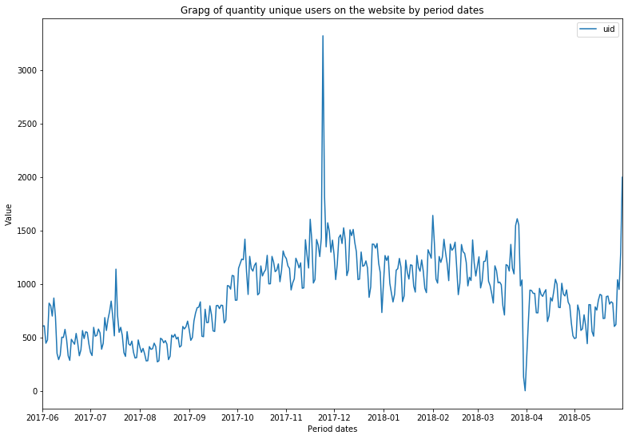

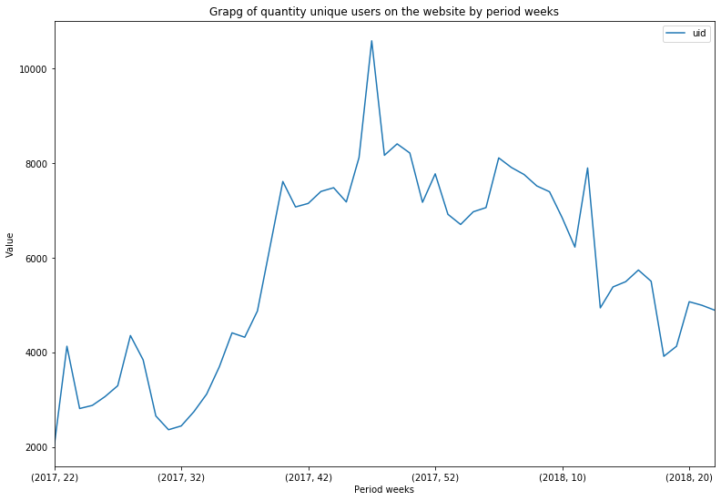

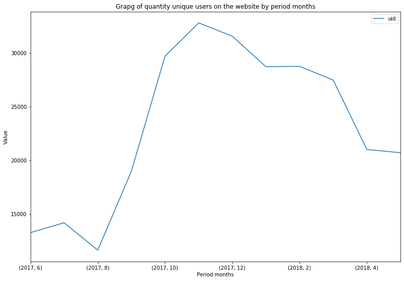

```python
#make cycle to draw graphs
list_user_metrics = {'dates':dau, 'weeks':wau, 'months':mau}
for name, value in list_user_metrics.items():
    value.plot(figsize=(13,9))
    plt.title('Grapg of quantity unique users on the website by period ' + name)
    plt.ylabel('Value')
    plt.xlabel('Period ' + name)
```

Metrics have periods of abnormal activity that most likely related to seasonal circumstances. For example in March 2018 we can see a rapid growth in user visits and then a rapid decline. Perhaps this is due to International Women's Day. As you know such purchases (tickets to movies, performances, etc.) have a clearly defined periodicity. If you take a user, you can find that he buys tickets (to the movies for example) with a certain frequency. Each client has its own strategy, but if an event occurs that forces the user to break their habits, their activity frequency is disrupted and we can see an uneven distribution of visits for this period on the graph. By analogy this works with other examples.

*The general periods of the greatest user activity are similar - from the end of August to the end of December and then the decline begins. This is due to the return of users from holidays after August and the gradual change in seasonal activities.*

Let's estimate value of visits by period

```python
#group our data by period and count uid
date_cnt = visits.groupby('ssn_date').agg({'uid':'count'})
week_cnt = visits.groupby(['ssn_year', 'ssn_week']).agg({'uid':'count'})
month_cnt = visits.groupby(['ssn_year', 'ssn_month']).agg({'uid':'count'})
```

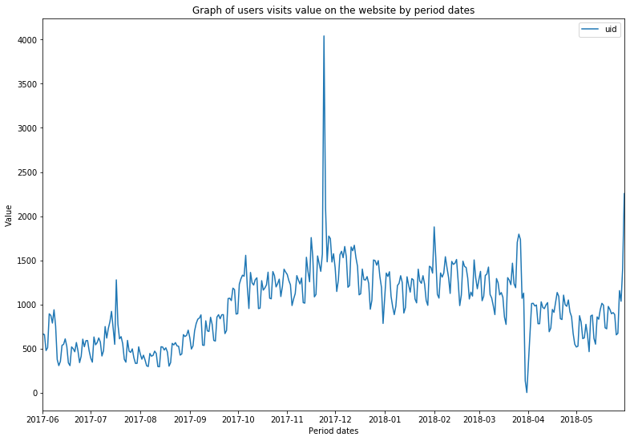

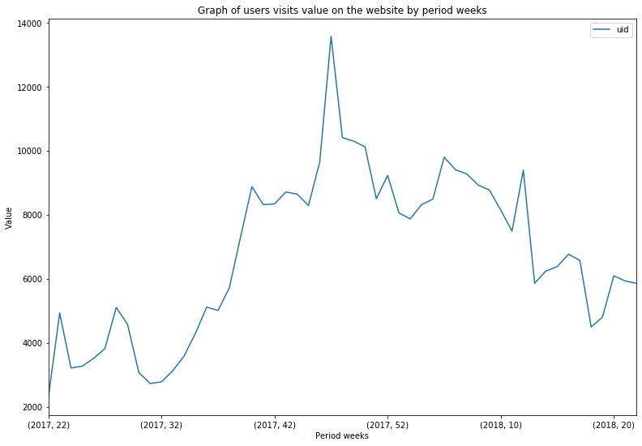

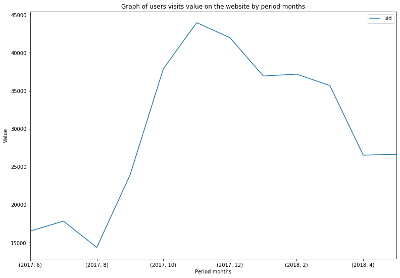

```python
#making cycle to draw graphs
list_user_metrics = {'dates':date_cnt, 'weeks':week_cnt, 'months':month_cnt}
for name, value in list_user_metrics.items():
    value.plot(figsize=(13,9))
    plt.title('Graph of users visits value on the website by period ' + name)
    plt.ylabel('Value')
    plt.xlabel('Period ' + name)
```

Let's count ASL (length of session activity) and build graph of middle length of user session.

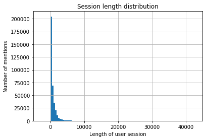

```python
visits['ssn_dur_sec'] = ( visits['end_ts'] - visits['start_ts'] ).dt.total_seconds()
visits['ssn_dur_sec'].hist(bins=100)
plt.title('Session length distribution')
plt.ylabel('Number of mentions')
plt.xlabel('Length of user session')
```

```python
asl = visits['ssn_dur_sec'].mode()
display(asl)
```

```
0    60.0
dtype: float64
```

```python
visits['ssn_dur_sec'].describe()
```

```
count    359400.000000
mean        643.025687
std         997.127761
min       -2760.000000
25%         120.000000
50%         300.000000
75%         840.000000
max       42660.000000
Name: ssn_dur_sec, dtype: float64
```

```python
first_activity_date = orders.groupby(['uid'])['buy_ts'].min()
first_activity_date.name = 'first_activity_date'
orders = orders.join(first_activity_date, on='uid')
orders.head()
```

|  | buy_ts | revenue | uid | first_activity_date |
| --- | --- | --- | --- | --- |
| 0 | 2017-06-01 00:10:00 | 17.00 | 10329302124590727494 | 2017-06-01 00:10:00 |
| 1 | 2017-06-01 00:25:00 | 0.55 | 11627257723692907447 | 2017-06-01 00:25:00 |
| 2 | 2017-06-01 00:27:00 | 0.37 | 17903680561304213844 | 2017-06-01 00:27:00 |
| 3 | 2017-06-01 00:29:00 | 0.55 | 16109239769442553005 | 2017-06-01 00:29:00 |
| 4 | 2017-06-01 07:58:00 | 0.37 | 14200605875248379450 | 2017-06-01 07:58:00 |

Select user cohorts and estimate Retention Rate

```python
orders['activity_month'] = orders['buy_ts'].astype('datetime64[M]')
orders['first_activity_month'] = orders['first_activity_date'].astype('datetime64[M]')

orders['cohort_lifetime'] =(
    orders['activity_month'] - orders['first_activity_month']
)
orders['cohort_lifetime'] = (
    orders['cohort_lifetime'] / np.timedelta64(1, 'M')
)
orders['cohort_lifetime'] = orders['cohort_lifetime'].round().astype('int')


cohorts = orders.groupby(['first_activity_month', 'cohort_lifetime']).agg({'uid':'nunique'}).reset_index()
display(cohorts)
```

|  | first_activity_month | cohort_lifetime | uid |
| --- | --- | --- | --- |
| 0 | 2017-06-01 | 0 | 2023 |
| 1 | 2017-06-01 | 1 | 61 |
| 2 | 2017-06-01 | 2 | 50 |
| 3 | 2017-06-01 | 3 | 54 |
| 4 | 2017-06-01 | 4 | 88 |
| ... | ... | ... | ... |
| 74 | 2018-03-01 | 2 | 58 |
| 75 | 2018-04-01 | 0 | 2276 |
| 76 | 2018-04-01 | 1 | 69 |
| 77 | 2018-05-01 | 0 | 2988 |
| 78 | 2018-06-01 | 0 | 1 |

79 rows × 3 columns

```python
initial_uid = cohorts[cohorts['cohort_lifetime'] == 0][
    ['first_activity_month', 'uid']
]
initial_uid = initial_uid.rename(columns={'uid':'cohort_uid'})

cohorts = cohorts.merge(initial_uid, on='first_activity_month')

display(cohorts)
```

|  | first_activity_month | cohort_lifetime | uid | cohort_uid |
| --- | --- | --- | --- | --- |
| 0 | 2017-06-01 | 0 | 2023 | 2023 |
| 1 | 2017-06-01 | 1 | 61 | 2023 |
| 2 | 2017-06-01 | 2 | 50 | 2023 |
| 3 | 2017-06-01 | 3 | 54 | 2023 |
| 4 | 2017-06-01 | 4 | 88 | 2023 |
| ... | ... | ... | ... | ... |
| 74 | 2018-03-01 | 2 | 58 | 3533 |
| 75 | 2018-04-01 | 0 | 2276 | 2276 |
| 76 | 2018-04-01 | 1 | 69 | 2276 |
| 77 | 2018-05-01 | 0 | 2988 | 2988 |
| 78 | 2018-06-01 | 0 | 1 | 1 |

79 rows × 4 columns

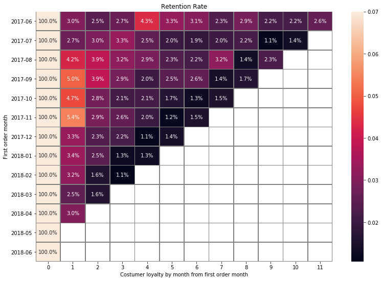

```python
cohorts['first_activity_month'] = cohorts['first_activity_month'].dt.strftime('%Y-%m')
cohorts['retention'] = cohorts['uid'] / cohorts['cohort_uid']

retention_pivot = cohorts.pivot_table(
    index='first_activity_month',
    columns='cohort_lifetime',
    values='retention',
    aggfunc='mean'
)

plt.figure(figsize=(13,9))
sns.heatmap(retention_pivot, fmt='.1%', annot=True, linewidth=0.7, linecolor='grey', vmax=0.07)
plt.title('Retention Rate')
plt.ylabel('First order month')
plt.xlabel('Costumer loyalty by month from first order month')
plt.show()
```

Apparently the number of unique users as well as the number of visits to Yandex.Afisha increases from August to the end of the year and then decreases by the summer period.

I think that in August user activity may increase due to the end of the holiday season and by the end of the year and in May due to the approaching holidays

```python
print('The average RR for the period of 2 months of life was -', (retention_pivot[1].mean() * 100).round(2))
```

```
The average RR for the period of 2 months of life was - 3.7
```

## E-commerce metrics

Let's see how much time passes from the first visit to the purchase

```python
orders_grouped = orders.groupby('uid')['buy_ts'].min()
orders_grouped.name = 'orders_ts'
time_visit_order = visits.join(orders_grouped, how='left', on='uid')
```

```python
time_visit_order = time_visit_order[time_visit_order['orders_ts'] > time_visit_order['start_ts']]
time_visit_order.head()
```

|  | device | end_ts | source_id | start_ts | uid | ssn_date | ssn_week | ssn_month | ssn_year | ssn_dur_sec | orders_ts |
| --- | --- | --- | --- | --- | --- | --- | --- | --- | --- | --- | --- |
| 5 | desktop | 2017-09-03 21:36:00 | 5 | 2017-09-03 21:35:00 | 16007536194108375387 | 2017-09-03 | 35 | 9 | 2017 | 60.0 | 2017-09-04 12:46:00 |
| 15 | touch | 2018-02-12 20:30:00 | 2 | 2018-02-12 19:24:00 | 18188358787673499603 | 2018-02-12 | 7 | 2 | 2018 | 3960.0 | 2018-02-12 19:48:00 |
| 27 | desktop | 2017-10-23 12:58:00 | 3 | 2017-10-23 12:49:00 | 4499746016005494365 | 2017-10-23 | 43 | 10 | 2017 | 540.0 | 2017-11-16 14:04:00 |
| 37 | desktop | 2018-03-12 23:25:00 | 3 | 2018-03-12 23:13:00 | 15857957287537270437 | 2018-03-12 | 11 | 3 | 2018 | 720.0 | 2018-03-12 23:17:00 |
| 38 | touch | 2018-03-01 08:45:00 | 4 | 2018-03-01 08:43:00 | 15763368622958393183 | 2018-03-01 | 9 | 3 | 2018 | 120.0 | 2018-03-06 18:33:00 |

```python
time_visit_order['time_visit_order'] = (time_visit_order['orders_ts'] - time_visit_order['start_ts']).dt.seconds
time_visit_order['time_visit_order'] = time_visit_order['time_visit_order'] / 60

display(time_visit_order['time_visit_order'].median())
display(time_visit_order['time_visit_order'].min())
display(time_visit_order['time_visit_order'].max())
```

```
32.0
```

```
0.0
```

```
1439.0
```

On average it takes 32 minutes from the start of the session to the purchase

Let's calculate the average number of purchases per customer for 6 months

```python
orders.head()
```

|  | buy_ts | revenue | uid | first_activity_date | activity_month | first_activity_month | cohort_lifetime |
| --- | --- | --- | --- | --- | --- | --- | --- |
| 0 | 2017-06-01 00:10:00 | 17.00 | 10329302124590727494 | 2017-06-01 00:10:00 | 2017-06-01 | 2017-06-01 | 0 |
| 1 | 2017-06-01 00:25:00 | 0.55 | 11627257723692907447 | 2017-06-01 00:25:00 | 2017-06-01 | 2017-06-01 | 0 |
| 2 | 2017-06-01 00:27:00 | 0.37 | 17903680561304213844 | 2017-06-01 00:27:00 | 2017-06-01 | 2017-06-01 | 0 |
| 3 | 2017-06-01 00:29:00 | 0.55 | 16109239769442553005 | 2017-06-01 00:29:00 | 2017-06-01 | 2017-06-01 | 0 |
| 4 | 2017-06-01 07:58:00 | 0.37 | 14200605875248379450 | 2017-06-01 07:58:00 | 2017-06-01 | 2017-06-01 | 0 |

```python
orders['first_activity_month'] = orders['first_activity_month'].astype('datetime64[M]')
orders['activity_month'] = orders['activity_month'].astype('datetime64[M]')

cohort_sizes = (
    orders.groupby('activity_month')
    .agg({'uid': ['nunique', 'count']})
    .reset_index()
)

cohort_sizes.columns = ['activity_month', 'n_buyers', 'cnt_orders']
cohort_sizes['orders_per_user'] = cohort_sizes['cnt_orders'] / cohort_sizes['n_buyers']
cohort_sizes['orders_per_user'] = round(cohort_sizes['orders_per_user'], 2)

cohort_sizes = cohort_sizes.query('activity_month >= "2017-05-01" and activity_month <= "2017-10-01" ')

display(cohort_sizes)
```

|  | activity_month | n_buyers | cnt_orders | orders_per_user |
| --- | --- | --- | --- | --- |
| 0 | 2017-06-01 | 2023 | 2354 | 1.16 |
| 1 | 2017-07-01 | 1984 | 2363 | 1.19 |
| 2 | 2017-08-01 | 1472 | 1807 | 1.23 |
| 3 | 2017-09-01 | 2750 | 3387 | 1.23 |
| 4 | 2017-10-01 | 4675 | 5679 | 1.21 |

On average users make 1-2 orders per month. We have taken into account the period from May to October 2017. Despite the increase in orders by September the number of orders per user is almost unchanged which indicates a weak life expectancy of an individual client on the platform.

```python
av_check = orders.groupby('activity_month').agg({'uid':'count', 'revenue':'sum'}).reset_index()

av_check['average_check'] = av_check['revenue'] / av_check['uid']
display(av_check)
```

|  | activity_month | uid | revenue | average_check |
| --- | --- | --- | --- | --- |
| 0 | 2017-06-01 | 2354 | 9557.49 | 4.060106 |
| 1 | 2017-07-01 | 2363 | 12539.47 | 5.306589 |
| 2 | 2017-08-01 | 1807 | 8758.78 | 4.847139 |
| 3 | 2017-09-01 | 3387 | 18345.51 | 5.416448 |
| 4 | 2017-10-01 | 5679 | 27987.70 | 4.928280 |
| 5 | 2017-11-01 | 5659 | 27069.93 | 4.783518 |
| 6 | 2017-12-01 | 6218 | 36388.60 | 5.852139 |
| 7 | 2018-01-01 | 4721 | 19417.13 | 4.112927 |
| 8 | 2018-02-01 | 5281 | 25560.54 | 4.840095 |
| 9 | 2018-03-01 | 5326 | 28834.59 | 5.413930 |
| 10 | 2018-04-01 | 3273 | 16858.06 | 5.150645 |
| 11 | 2018-05-01 | 4346 | 20735.98 | 4.771279 |
| 12 | 2018-06-01 | 1 | 3.42 | 3.420000 |

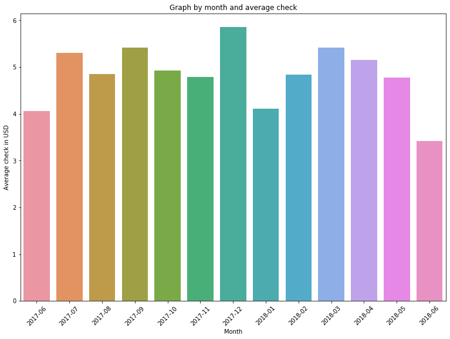

```python
av_check['activity_month'] = av_check['activity_month'].dt.strftime('%Y-%m')


plt.figure(figsize=(13, 9))
sns.barplot(data=av_check ,x='activity_month', y='average_check')
plt.title('Graph by month and average check')
plt.xlabel('Month')
plt.ylabel('Average check in USD')
plt.xticks(rotation=45)
```

Let's calculate LTV (lifetime value) and build the graph

```python
uids_sources = visits.groupby('uid', as_index=False).agg({'source_id':'first'})

orders = orders.merge(uids_sources, on='uid')
orders.head()
```

|  | buy_ts | revenue | uid | first_activity_date | activity_month | first_activity_month | cohort_lifetime | source_id |
| --- | --- | --- | --- | --- | --- | --- | --- | --- |
| 0 | 2017-06-01 00:10:00 | 17.00 | 10329302124590727494 | 2017-06-01 00:10:00 | 2017-06-01 | 2017-06-01 | 0 | 1 |
| 1 | 2017-06-01 00:25:00 | 0.55 | 11627257723692907447 | 2017-06-01 00:25:00 | 2017-06-01 | 2017-06-01 | 0 | 2 |
| 2 | 2017-06-01 00:27:00 | 0.37 | 17903680561304213844 | 2017-06-01 00:27:00 | 2017-06-01 | 2017-06-01 | 0 | 2 |
| 3 | 2017-06-01 00:29:00 | 0.55 | 16109239769442553005 | 2017-06-01 00:29:00 | 2017-06-01 | 2017-06-01 | 0 | 2 |
| 4 | 2017-06-01 07:58:00 | 0.37 | 14200605875248379450 | 2017-06-01 07:58:00 | 2017-06-01 | 2017-06-01 | 0 | 3 |

```python
cohort_sizes = (
    orders.groupby(['source_id', 'first_activity_month'])
    .agg({'uid': 'nunique'})
    .reset_index()
)
cohort_sizes.columns = ['source_id', 'first_activity_month', 'n_buyers']

cohorts = (
    orders.groupby(['source_id', 'first_activity_month', 'activity_month'])
    .agg({'revenue': 'sum'})
    .reset_index()
)

report = pd.merge(cohorts, cohort_sizes, on=['source_id', 'first_activity_month'])
report.head()
```

|  | source_id | first_activity_month | activity_month | revenue | n_buyers |
| --- | --- | --- | --- | --- | --- |
| 0 | 1 | 2017-06-01 | 2017-06-01 | 1168.45 | 203 |
| 1 | 1 | 2017-06-01 | 2017-07-01 | 362.94 | 203 |
| 2 | 1 | 2017-06-01 | 2017-08-01 | 153.72 | 203 |
| 3 | 1 | 2017-06-01 | 2017-09-01 | 695.88 | 203 |
| 4 | 1 | 2017-06-01 | 2017-10-01 | 760.74 | 203 |

```python
margin_rate = 1

report['gp'] = report['revenue'] * margin_rate

report['age'] = (report['activity_month'] - report['first_activity_month']) / np.timedelta64(1, 'M')

report['age'] = report['age'].round().astype('int')

report['ltv'] = report['gp'] / report['n_buyers']

report['first_activity_month'] = report['first_activity_month'].dt.strftime('%Y-%m')
```

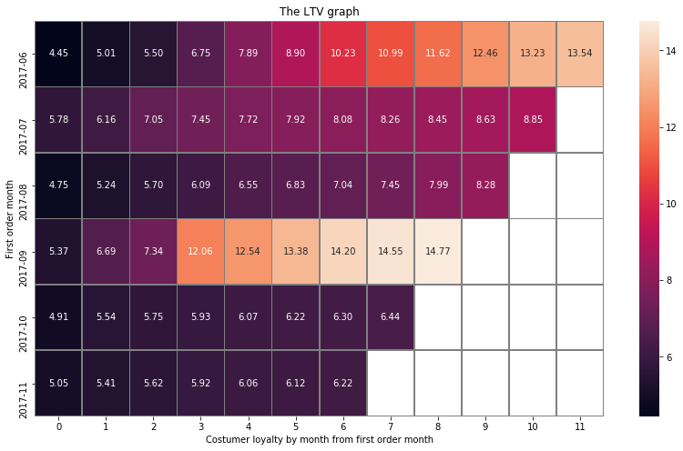

```python
output = report.pivot_table(index='first_activity_month', columns='age', values='ltv', aggfunc='mean').cumsum(axis=1).round(2)

output = output.query('index >= "2017-05" and index <= "2017-11"')

plt.figure(figsize=(14,8))
sns.heatmap(output, fmt='.2f', annot=True, linewidth=0.7, linecolor='grey')
plt.title('The LTV graph')
plt.ylabel('First order month')
plt.xlabel('Costumer loyalty by month from first order month')
plt.show()
```

```python
m6_cum_ltv = output.mean(axis=0)[6]
print('Average LTV for 6 months after first order:', m6_cum_ltv)
```

```
Average LTV for 6 months after first order: 8.678333333333333
```

## Marketing metrics

Let's calculate the total amount of marketing expenses and find out the expenses by source.

```python
costs['month'] = costs['date_marketing'].astype('datetime64[M]')
costs.head()
```

|  | source_id | date_marketing | costs | month |
| --- | --- | --- | --- | --- |
| 0 | 1 | 2017-06-01 | 75.20 | 2017-06-01 |
| 1 | 1 | 2017-06-02 | 62.25 | 2017-06-01 |
| 2 | 1 | 2017-06-03 | 36.53 | 2017-06-01 |
| 3 | 1 | 2017-06-04 | 55.00 | 2017-06-01 |
| 4 | 1 | 2017-06-05 | 57.08 | 2017-06-01 |

```python
costs_all = costs['costs'].sum()
display(costs_all)
```

```
329131.62
```

The total amount of marketing expenses is 329131.62 USD.

```python
costs_per_source = costs.groupby('source_id').agg({'costs':'sum'})
display(costs_per_source)
```

| source_id | costs |
| --- | --- |
| 1 | 20833.27 |
| 2 | 42806.04 |
| 3 | 141321.63 |
| 4 | 61073.60 |
| 5 | 51757.10 |
| 9 | 5517.49 |
| 10 | 5822.49 |

Source number 3 is the most expensive and source number 9 is the least expensive. The top three in terms of costs are the 3rd, 4th and 5th.

```python
costs['month'] = costs['month'].dt.strftime('%Y-%m')
costs_pivot = costs.pivot_table(
    index='source_id',
    columns='month',
    values='costs',
    aggfunc='sum'
)

display(costs_pivot)
```

| month source_id | 2017-06 | 2017-07 | 2017-08 | 2017-09 | 2017-10 | 2017-11 | 2017-12 | 2018-01 | 2018-02 | 2018-03 | 2018-04 | 2018-05 |
| --- | --- | --- | --- | --- | --- | --- | --- | --- | --- | --- | --- | --- |
| 1 | 1125.61 | 1072.88 | 951.81 | 1502.01 | 2315.75 | 2445.16 | 2341.20 | 2186.18 | 2204.48 | 1893.09 | 1327.49 | 1467.61 |
| 2 | 2427.38 | 2333.11 | 1811.05 | 2985.66 | 4845.00 | 5247.68 | 4897.80 | 4157.74 | 4474.34 | 3943.14 | 2993.70 | 2689.44 |
| 3 | 7731.65 | 7674.37 | 6143.54 | 9963.55 | 15737.24 | 17025.34 | 16219.52 | 14808.78 | 14228.56 | 13080.85 | 9296.81 | 9411.42 |
| 4 | 3514.80 | 3529.73 | 3217.36 | 5192.26 | 6420.84 | 5388.82 | 7680.47 | 5832.79 | 5711.96 | 5961.87 | 4408.49 | 4214.21 |
| 5 | 2616.12 | 2998.14 | 2185.28 | 3849.14 | 5767.40 | 6325.34 | 5872.52 | 5371.52 | 5071.31 | 4529.62 | 3501.15 | 3669.56 |
| 9 | 285.22 | 302.54 | 248.93 | 415.62 | 609.41 | 683.18 | 657.98 | 547.16 | 551.50 | 480.29 | 373.49 | 362.17 |
| 10 | 314.22 | 329.82 | 232.57 | 460.67 | 627.24 | 792.36 | 645.86 | 614.35 | 480.88 | 526.41 | 388.25 | 409.86 |

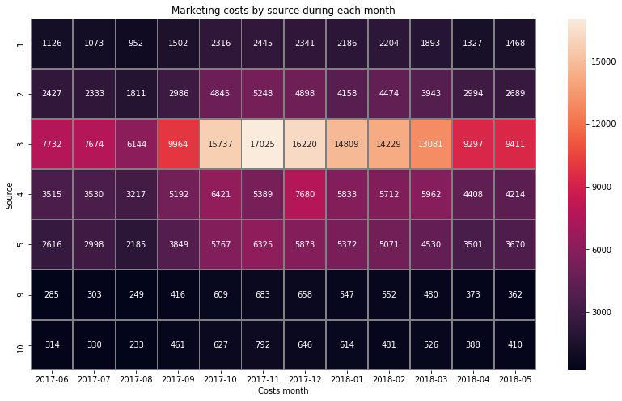

```python
plt.figure(figsize=(14,8))
sns.heatmap(costs_pivot, fmt='.0f', annot=True, linewidth=0.7, linecolor='grey')
plt.title('Marketing costs by source during each month')
plt.ylabel('Source')
plt.xlabel('Costs month')
plt.show()
```

In each source costs gradually decrease by the end of August and increase sharply from September to December. After the new year costs begin to gradually decrease.

Let's calculate in general CAC (costumer acquisition cost) for all over the project and for each source separately.

```python
visits['month'] = visits['start_ts'].astype('datetime64[M]')
visits['month'] = visits['month'].dt.strftime('%Y-%m')

visits_source_month = visits.groupby(['month', 'source_id']).agg({'uid':'nunique'}).reset_index()
```

```python
visits.head()
```

|  | device | end_ts | source_id | start_ts | uid | ssn_date | ssn_week | ssn_month | ssn_year | ssn_dur_sec | month |
| --- | --- | --- | --- | --- | --- | --- | --- | --- | --- | --- | --- |
| 0 | touch | 2017-12-20 17:38:00 | 4 | 2017-12-20 17:20:00 | 16879256277535980062 | 2017-12-20 | 51 | 12 | 2017 | 1080.0 | 2017-12 |
| 1 | desktop | 2018-02-19 17:21:00 | 2 | 2018-02-19 16:53:00 | 104060357244891740 | 2018-02-19 | 8 | 2 | 2018 | 1680.0 | 2018-02 |
| 2 | touch | 2017-07-01 01:54:00 | 5 | 2017-07-01 01:54:00 | 7459035603376831527 | 2017-07-01 | 26 | 7 | 2017 | 0.0 | 2017-07 |
| 3 | desktop | 2018-05-20 11:23:00 | 9 | 2018-05-20 10:59:00 | 16174680259334210214 | 2018-05-20 | 20 | 5 | 2018 | 1440.0 | 2018-05 |
| 4 | desktop | 2017-12-27 14:06:00 | 3 | 2017-12-27 14:06:00 | 9969694820036681168 | 2017-12-27 | 52 | 12 | 2017 | 0.0 | 2017-12 |

```python
orders.head()
```

|  | buy_ts | revenue | uid | first_activity_date | activity_month | first_activity_month | cohort_lifetime | source_id |
| --- | --- | --- | --- | --- | --- | --- | --- | --- |
| 0 | 2017-06-01 00:10:00 | 17.00 | 10329302124590727494 | 2017-06-01 00:10:00 | 2017-06-01 | 2017-06-01 | 0 | 1 |
| 1 | 2017-06-01 00:25:00 | 0.55 | 11627257723692907447 | 2017-06-01 00:25:00 | 2017-06-01 | 2017-06-01 | 0 | 2 |
| 2 | 2017-06-01 00:27:00 | 0.37 | 17903680561304213844 | 2017-06-01 00:27:00 | 2017-06-01 | 2017-06-01 | 0 | 2 |
| 3 | 2017-06-01 00:29:00 | 0.55 | 16109239769442553005 | 2017-06-01 00:29:00 | 2017-06-01 | 2017-06-01 | 0 | 2 |
| 4 | 2017-06-01 07:58:00 | 0.37 | 14200605875248379450 | 2017-06-01 07:58:00 | 2017-06-01 | 2017-06-01 | 0 | 3 |

```python
n_buyers_all = orders.groupby('activity_month').agg({'uid':'nunique'}).sum()
display(n_buyers_all)
```

```
uid    41019
dtype: int64
```

```python
cac_all = costs_all / n_buyers_all
display(cac_all)
```

```
uid    8.023882
dtype: float64
```

```python
monthly_costs = costs.groupby(['month', 'source_id'])['costs'].sum().reset_index()
monthly_costs.head()
```

|  | month | source_id | costs |
| --- | --- | --- | --- |
| 0 | 2017-06 | 1 | 1125.61 |
| 1 | 2017-06 | 2 | 2427.38 |
| 2 | 2017-06 | 3 | 7731.65 |
| 3 | 2017-06 | 4 | 3514.80 |
| 4 | 2017-06 | 5 | 2616.12 |

```python
visits_source_month.head()
```

|  | month | source_id | uid |
| --- | --- | --- | --- |
| 0 | 2017-06 | 1 | 972 |
| 1 | 2017-06 | 2 | 1532 |
| 2 | 2017-06 | 3 | 4226 |
| 3 | 2017-06 | 4 | 3636 |
| 4 | 2017-06 | 5 | 2903 |

```python
monthly_costs = monthly_costs.merge(
    visits_source_month, on=['month', 'source_id']
)
```

```python
report_new = pd.merge(
    monthly_costs, report, left_on=['month', 'source_id'], right_on=['first_activity_month', 'source_id']
)

report_new['cac'] = report_new['costs'] / report_new['n_buyers']
display(report_new)
```

|  | month | source_id | costs | uid | first_activity_month | activity_month | revenue | n_buyers | gp | age | ltv | cac |
| --- | --- | --- | --- | --- | --- | --- | --- | --- | --- | --- | --- | --- |
| 0 | 2017-06 | 1 | 1125.61 | 972 | 2017-06 | 2017-06-01 | 1168.45 | 203 | 1168.45 | 0 | 5.755911 | 5.544877 |
| 1 | 2017-06 | 1 | 1125.61 | 972 | 2017-06 | 2017-07-01 | 362.94 | 203 | 362.94 | 1 | 1.787882 | 5.544877 |
| 2 | 2017-06 | 1 | 1125.61 | 972 | 2017-06 | 2017-08-01 | 153.72 | 203 | 153.72 | 2 | 0.757241 | 5.544877 |
| 3 | 2017-06 | 1 | 1125.61 | 972 | 2017-06 | 2017-09-01 | 695.88 | 203 | 695.88 | 3 | 3.427980 | 5.544877 |
| 4 | 2017-06 | 1 | 1125.61 | 972 | 2017-06 | 2017-10-01 | 760.74 | 203 | 760.74 | 4 | 3.747488 | 5.544877 |
| ... | ... | ... | ... | ... | ... | ... | ... | ... | ... | ... | ... | ... |
| 508 | 2018-05 | 3 | 9411.42 | 5343 | 2018-05 | 2018-05-01 | 2990.65 | 785 | 2990.65 | 0 | 3.809745 | 11.989070 |
| 509 | 2018-05 | 4 | 4214.21 | 7275 | 2018-05 | 2018-05-01 | 3616.23 | 767 | 3616.23 | 0 | 4.714772 | 5.494407 |
| 510 | 2018-05 | 5 | 3669.56 | 4038 | 2018-05 | 2018-05-01 | 2103.24 | 510 | 2103.24 | 0 | 4.124000 | 7.195216 |
| 511 | 2018-05 | 9 | 362.17 | 753 | 2018-05 | 2018-05-01 | 200.38 | 53 | 200.38 | 0 | 3.780755 | 6.833396 |
| 512 | 2018-05 | 10 | 409.86 | 777 | 2018-05 | 2018-05-01 | 478.93 | 117 | 478.93 | 0 | 4.093419 | 3.503077 |

513 rows × 12 columns

```python
source_cac = report_new.pivot_table(
    index='source_id',
    columns='age',
    values='cac',
    aggfunc='mean'
)

display(source_cac)
```

| age source_id | 0 | 1 | 2 | 3 | 4 | 5 | 6 | 7 | 8 | 9 | 10 | 11 |
| --- | --- | --- | --- | --- | --- | --- | --- | --- | --- | --- | --- | --- |
| 1 | 5.600034 | 5.674538 | 5.700159 | 5.729075 | 5.646485 | 5.526385 | 5.595484 | 5.632652 | 5.625320 | 5.731274 | 5.314808 | 5.544877 |
| 2 | 10.087368 | 10.459870 | 10.317881 | 10.320378 | 10.134720 | 9.850867 | 9.895222 | 9.840281 | 9.868123 | 9.957433 | 9.017685 | 8.957122 |
| 3 | 15.884857 | 16.239020 | 16.078505 | 16.163100 | 16.353683 | 16.192237 | 16.523822 | 16.519482 | 16.844411 | 17.326010 | 15.396704 | 13.469774 |
| 4 | 6.687370 | 6.795822 | 6.809469 | 6.913436 | 7.091741 | 7.271592 | 7.490445 | 8.030521 | 8.586787 | 8.480347 | 7.830915 | 8.428777 |
| 5 | 7.553257 | 7.585806 | 7.541371 | 7.485356 | 7.477701 | 7.359916 | 7.262140 | 6.789045 | 6.932589 | 7.050210 | 7.274288 | 7.109022 |
| 9 | 4.301936 | 4.071803 | 3.700879 | 3.834142 | 3.719121 | 3.478545 | 3.479976 | 3.317200 | 3.440698 | 2.866289 | 3.401496 | NaN |
| 10 | 5.259864 | 5.143985 | 5.472223 | 6.060143 | 5.170574 | 7.320679 | 5.839062 | 6.530117 | 5.193141 | NaN | NaN | 3.611724 |

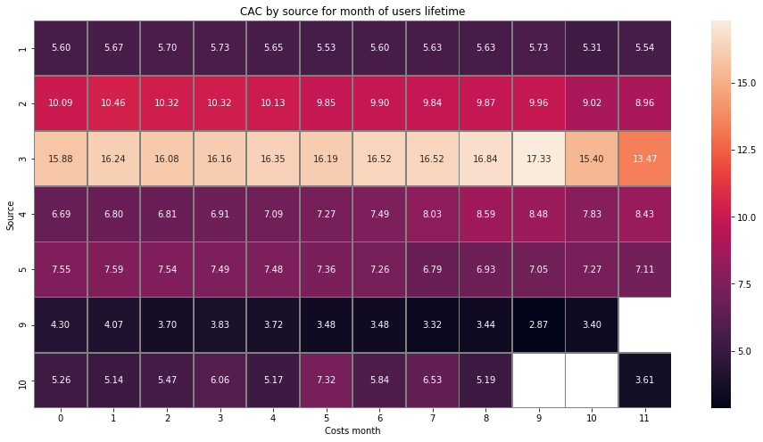

```python
plt.figure(figsize=(16,8))
sns.heatmap(source_cac, fmt='.2f', annot=True, linewidth=0.7, linecolor='grey')
plt.title('CAC by source for month of users lifetime')
plt.ylabel('Source')
plt.xlabel('Costs month')
plt.show()
```

The cost of attracting a single user for each of the sources increases by October and from November to January sharply decreases increasing again from February. Source number 3 is the most expensive to attract a single user.

Let's calculate the ROMI (return on marketing investment) for cohorts in the context of sources. So compare the payback for the same life periods of the cohorts.

```python
report_new['romi'] = report_new['ltv'] / report_new['cac']
report_new.head()
```

|  | month | source_id | costs | uid | first_activity_month | activity_month | revenue | n_buyers | gp | age | ltv | cac | romi |
| --- | --- | --- | --- | --- | --- | --- | --- | --- | --- | --- | --- | --- | --- |
| 0 | 2017-06 | 1 | 1125.61 | 972 | 2017-06 | 2017-06-01 | 1168.45 | 203 | 1168.45 | 0 | 5.755911 | 5.544877 | 1.038059 |
| 1 | 2017-06 | 1 | 1125.61 | 972 | 2017-06 | 2017-07-01 | 362.94 | 203 | 362.94 | 1 | 1.787882 | 5.544877 | 0.322439 |
| 2 | 2017-06 | 1 | 1125.61 | 972 | 2017-06 | 2017-08-01 | 153.72 | 203 | 153.72 | 2 | 0.757241 | 5.544877 | 0.136566 |
| 3 | 2017-06 | 1 | 1125.61 | 972 | 2017-06 | 2017-09-01 | 695.88 | 203 | 695.88 | 3 | 3.427980 | 5.544877 | 0.618225 |
| 4 | 2017-06 | 1 | 1125.61 | 972 | 2017-06 | 2017-10-01 | 760.74 | 203 | 760.74 | 4 | 3.747488 | 5.544877 | 0.675847 |

```python
source_list = [ 1,  2,  3,  4,  5,  9, 10]
```

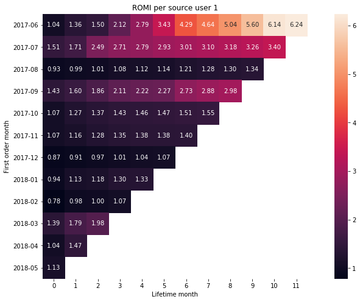

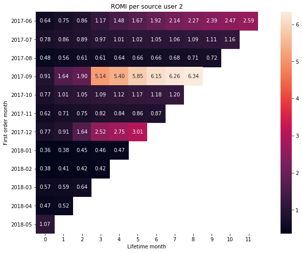

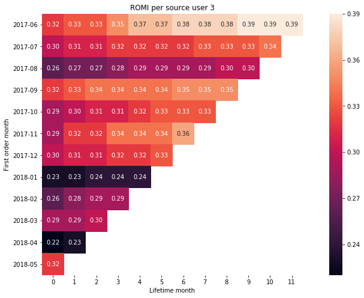

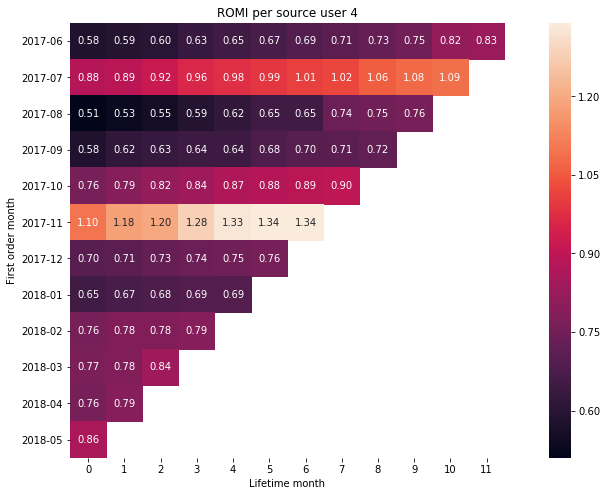

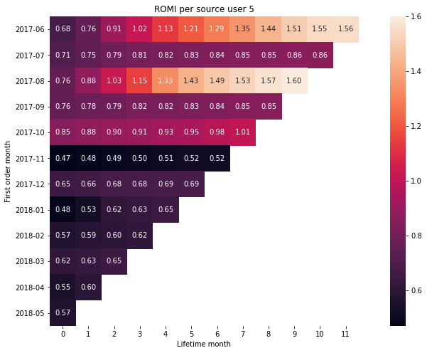

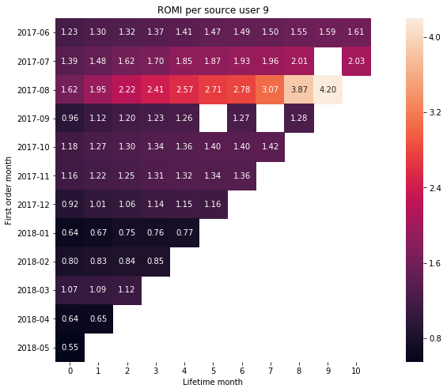

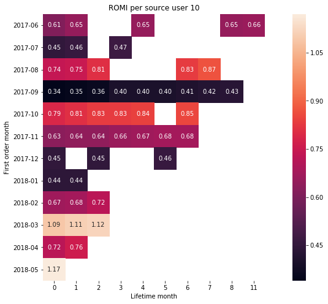

```python
for i in source_list:
    plt.figure(figsize=(16,8))
    romi_pivot = report_new[report_new['source_id'] == i].pivot_table(
        index='first_activity_month',
        columns='age',
        values='romi',
        aggfunc='mean').cumsum(axis=1).round(2)
    sns.heatmap(romi_pivot, fmt='.2f', annot=True, linecolor='grey', square=True)
    plt.title('ROMI per source user {}' .format(i))
    plt.ylabel('First order month')
    plt.xlabel('Lifetime month')
    plt.show()
```

# Conclusions and recomendations

### The conclusions description of each type metrics: marketing, product, and e-commerce metrics:

#### Product's metrics:

Apparently the number of unique users as well as the number of visits to Yandex.Afisha,increases from August to the end of the year and then decreases by the summer period.

I think that in August user activity may increase due to the end of the holiday season and by the end of the year and in May due to the approaching holidays.

#### E-commerce metrics:

On average it takes 32 minutes from the start of the session to the purchase.

On average users make 1-2 orders per month. We have taken into account the period from May to October 2017. Despite the increase in orders by September the number of orders per user is almost unchanged which indicates a weak customer retention after the first purchase.

The average monthly check does not change significantly except in December. Before the new year the average check increases dramatically.

#### Marketing metrics:

Source number 3 is the most expensive, and source number 9 is the least expensive. The top three in terms of costs are the 3rd, 4th and 5th.

The total amount spent on marketing is 329 thousand USD.

Periods of marketing activity - In each source, costs gradually decrease by the end of August and increase sharply from September to December. After the new year, costs begin to gradually decrease.

The cost of attracting a single user for each of the sources increases by October and from November to January sharply decreases, increasing again from February. Source number 3 is the most expensive to attract a single user.